# Functional analysis of microarray data in RStudio

## Diego Montesinos Valencia 2020

- This tutorial is a variant of the tutorial created by Dr. Ricardo A. Verdugo (2011)
- This experiment is an expression profile made on the Illumina Mouse-Ref8 platform
- Focuses on evaluating the effect of genetic variation on the mouse Y chromosome on the size of cardiomyocytes.
- NOTE: It is necessary to have installed the packages “preprocessCore”, “factoextra” and “ggplot2”

## Initial issues

# ———————————————————————————

Choose bin as the working directory, this is where this same script is located

Create the output directory, it will be found in the “../data” directory

```r
outdir     <- "../data/output"

if(!file.exists(outdir)) {
  dir.create(outdir, mode = "0755", recursive=T)
}
```

## Load and prepare microarray information in Illumina format

# ———————————————————————————

```r
RAW  <- read.delim("../data/DATA_RAW.txt", header = TRUE) # Upload all raw information
```

Choose only 5000 rows (Only 5000 are chosen to streamline analysis)

```r
Data.Raw <- RAW[sample(nrow(RAW), 5000), ]

signal    <- grep("CDR", colnames(Data.Raw)) # Column vector with data
detection <- grep("Detection.Pval", colnames(Data.Raw)) # Column vector with p-values
head(Data.Raw) # Observe "Data.Raw"
```

```
##             ID_REF     CDR017 Detection.Pval BEAD_STDERR Avg_NBEADS     CDR025
## 14763 ILMN_1253860  102.84690      0.1892231    6.899680         33   80.71502
## 14511 ILMN_2748897   96.33149      0.2443609    5.344383         36   80.37609
## 25488 ILMN_2814051 1388.92900      0.0000000   43.830820         31 1194.82300
## 4525  ILMN_2794276  112.50000      0.1152882    6.657141         38  107.61720
## 9962  ILMN_1229161 1418.32600      0.0000000   38.243260         41 1481.34600
## 8931  ILMN_2691067  174.42980      0.0112782   14.204880         27  171.30920
##       Detection.Pval.1 BEAD_STDERR.1 Avg_NBEADS.1     CDR021 Detection.Pval.2
## 14763      0.372180500      3.853089           41  101.49410      0.187969900
## 14511      0.373433600      3.701604           34   82.34319      0.449874700
## 25488      0.000000000     47.915800           33 1574.21000      0.000000000
## 4525       0.100250600      9.212885           24  127.68400      0.065162900
## 9962       0.000000000     63.376700           38 1302.27200      0.000000000
## 8931       0.006265664     22.547450           16  210.18120      0.001253133
##       BEAD_STDERR.2 Avg_NBEADS.2     CDR029 Detection.Pval.3 BEAD_STDERR.3
```

[output cut: 83 more lines]

Load annotations from the probe

```r
annot <- read.delim("../data/MouseRef-8_annot_full.txt") # Load the file with all the annotation information
data_names <- rownames(Data.Raw)
annot = annot[row.names(annot)%in%data_names,] # Choose only 5000 "Data.Raw" annotations

head(annot) # Observe "annot"
```

```
##         ProbeID                                           Sequence ProbeQuality
## 16 ILMN_2737647 CGTGCCCACCTCCTCGGCTAATGCCCTTTTGGGGTTGTGGGGAGGATGAA      Perfect
## 20 ILMN_2952292 CTTGCCTTGGTCATGATGTCTGCTCACAGCCTTAAAACCCTTAAAACACT          Bad
## 21 ILMN_2699078 TTAATTAGTACTGAATATTGTGATTTCTTATTTGAGAACTAGAATGACTT      Perfect
## 24 ILMN_1219797 GGAAGTGCTCTTGATCCACTTGCTGATAAAGTTCTTATCAGCATCTTATA      Perfect
## 30 ILMN_2836586 TCTGGCTGCCAGGTGGGAACCTGGGCCCAGACCACTCAGCTCCTAGCACA      Perfect
## 34 ILMN_2807229 ACTTCAGTCAAGGGAGCAGTTCAAAGAGCACACCGGCGTCCCCAGAGCCA      Perfect
##        CodingZone EntrezID            Ensembl  Symbol
## 16 Transcriptomic    68316 ENSMUSG00000079508    Apoo
## 20 Transcriptomic    66055 ENSMUSG00000037361   Sf3b6
## 21 Transcriptomic    66055 ENSMUSG00000037361   Sf3b6
## 24 Transcriptomic    66586 ENSMUSG00000027357   Crls1
## 30 Transcriptomic    68294 ENSMUSG00000001082  Mfsd10
## 34 Transcriptomic    68339 ENSMUSG00000021182 Ccdc88c
```

Load hybridization design

```r
design <- read.csv("../data/YChrom_design.csv")
head(design) # Observe "design"
```

```
##   Array Sample_Name Sentrix_ID Sentrix_Position Genotype Treatment Group
## 1     1  CDR017-DIL 4340571022                A        B         I   B.I
## 2     2      CDR025 4340571022                B       BY         I  BY.I
## 3     3      CDR021 4340571022                C        B         C   B.C
## 4     4  CDR029-DIL 4340571022                D       BY         C  BY.C
## 5     5      CDR022 4340571022                E        B         C   B.C
## 6     6      CDR018 4340571022                F        B         I   B.I
```

## QC probe filtering

# ———————————————————————————

Because not all probes have the same quality from sequence alignment to genome

```r
table(annot$ProbeQuality)
```

```
##
##         Bad        Good     Good***    Good****    No match     Perfect
##         270          86           2          29          10        4445
##  Perfect*** Perfect****
##          36         122
```

We will group ‘Bad’ with ‘No match’ as bad and everything else as good

```r
probe_qc <- ifelse(annot$ProbeQuality %in% c("Bad", "No match"), "Bad probes", "Good probes")
```

Since poor quality probes tend to have a lower signal than good probes it is recommended to remove them

```r
Data.Raw <- Data.Raw[probe_qc %in% "Good probes",]
annot    <- annot[probe_qc %in% "Good probes",]
```

Create raw data matrix

```r
rawdata           <- as.matrix(Data.Raw[,signal])
rownames(rawdata) <- Data.Raw$PROBE_ID
colnames(rawdata) <- design$Sample_Name
```

## Data normalization

# ———————————————————————————

```r
library(preprocessCore)
normdata           <- normalize.quantiles(rawdata)
colnames(normdata) <- colnames(rawdata)
rownames(normdata) <- rownames(rawdata)
```

## Filtering the probe

# ———————————————————————————

Create a vector or P / A calls for each probe using detection probabilities calculated by BeadStudio

```r
probe_present      <- Data.Raw[,detection] < 0.04
detected_per_group <- t(apply(probe_present, 1, tapply, design$Group, sum))

present  <- apply(detected_per_group >= 2, 1, any)
normdata <- normdata[present,]
annot    <- annot[present, ]
```

Write the file “normdata.txt” with the data already normalized

```r
write.table(normdata, file.path(outdir, "normdata.txt"), sep="\t", row.names=T)
```

## Continue with the functional analysis of the data

# ———————————————————————————

Import the normalized data (contained in the file “normdata.txt”)

```r
mydata <- read.delim("../data/output/normdata.txt", as.is=T)
```

Change column names to make it easier to identify the experimental group in the following graphs

```r
design <- read.csv("../data/YChrom_design.csv")
colnames(mydata) <- design$Group
```

Delete as missing list and standardize variables

```r
mydata <- na.omit (mydata)
mydata <- scale (mydata)
```

Determine the number of groups using k-means

```r
wss <- (nrow(mydata)-1)*sum(apply(mydata,2,var))
for (i in 2:15) wss[i] <- sum(kmeans(mydata,
                                     centers=i)$withinss)
```

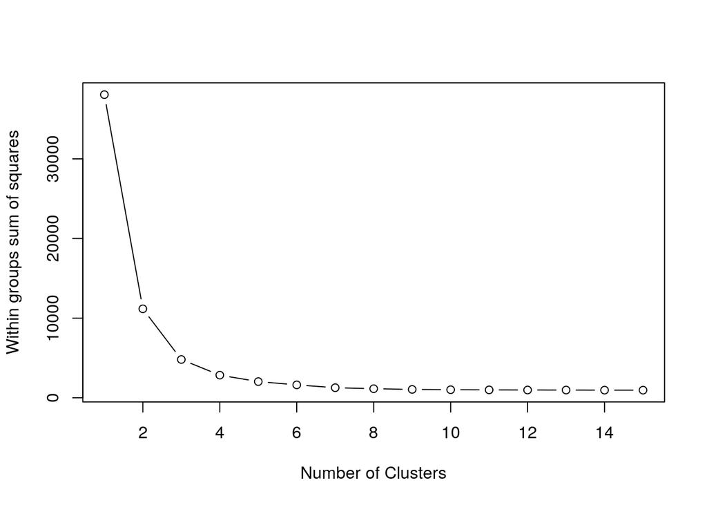

```r
plot(1:15, wss, type="b", xlab="Number of Clusters",
     ylab="Within groups sum of squares")
```

In this case, the k = 4 was taken as the inflection point

# K-Means Cluster Analysis

# ———————————————————————————

```r
fit <- kmeans(mydata, 4) # 4 is the cluster solution
```

Get cluster means

```r
aggregate(mydata,by=list(fit$cluster),FUN=mean)
```

```
##   Group.1        B.I       BY.I        B.C       BY.C        B.C        B.I
## 1       1 -0.2219892 -0.2221125 -0.2220572 -0.2218791 -0.2218116 -0.2220147
## 2       2  1.0368105  1.0293479  1.0273218  1.0296991  1.0277456  1.0339128
## 3       3  8.5053194  8.4895046  8.5053877  8.4895621  8.4893436  8.5053593
## 4       4  3.6674041  3.7231344  3.7207841  3.7065218  3.7124968  3.6839940
##         BY.I       BY.C       BY.C        B.C       BY.I        B.I        B.I
## 1 -0.2220279 -0.2219135 -0.2219223 -0.2218006 -0.2219313 -0.2218219 -0.2219356
## 2  1.0279639  1.0303083  1.0259123  1.0230452  1.0263705  1.0400805  1.0277711
## 3  8.4654490  8.5054038  8.4895537  8.5053167  8.4137412  8.4792852  8.5053329
## 4  3.7390971  3.6962260  3.7288618  3.7267374  3.7716567  3.6552141  3.7108023
##         BY.I      BY.C        B.C
## 1 -0.2217381 -0.221926 -0.2217307
## 2  1.0306818  1.026762  1.0280583
## 3  8.4273142  8.505384  8.5052614
## 4  3.7291371  3.715385  3.6964004
```

Append cluster assignment

```r
library(factoextra)
```

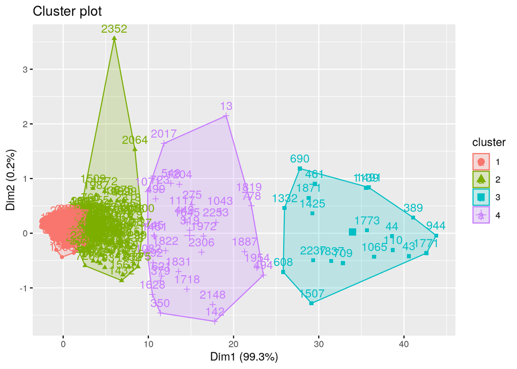

```r
fviz_cluster(fit, data = mydata)
```

```r
mydata <- data.frame(mydata, fit$cluster)
```

Hierarchical cluster

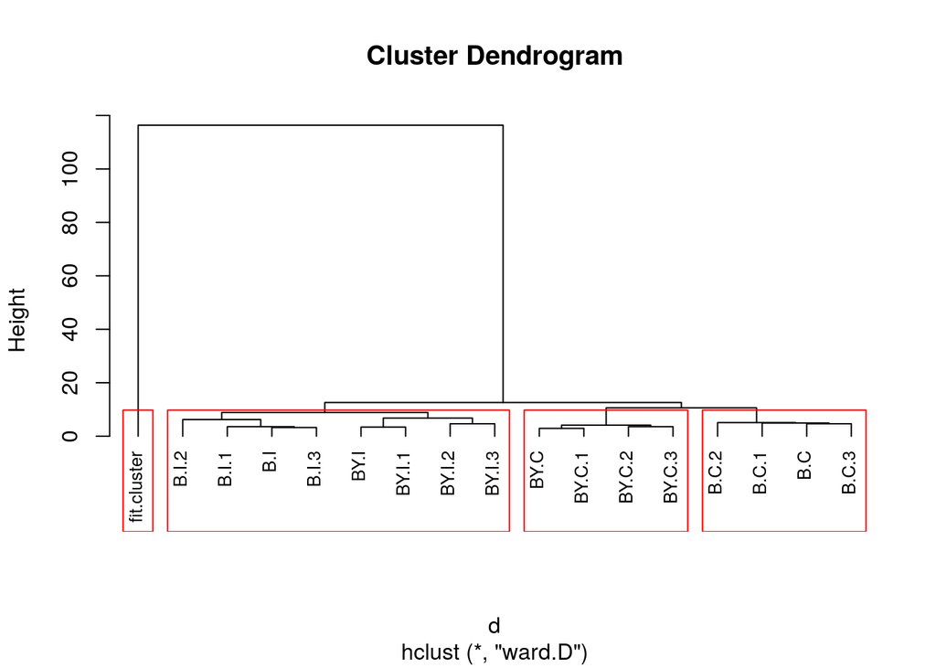

```r
d <- dist(t(mydata), method = "euclidean") # Distance matrix("euclidean")
fit <- hclust(d, method="ward.D")
plot(fit, hang = -1, cex = 0.8) # Display dendogram
groups <- cutree(fit, k=4) # Cut tree into 4 clusters
rect.hclust(fit, k=4, border="red") # Draw dendogram with red borders around the 4 clusters
```